# Analysis of 10x PBMC 4k dataset

### 7.2.5 Infer cell types using Seurat and scCATCH

Check the package version.

```r
packageVersion("scCATCH")
```

```
[1] ‘3.0’
```

Load Seurat computational results.

```r
pbmc <- readRDS("backup/04_021_pbmc4k_seurat.rds")
```

Create scCATCH objects.

```r
mat <- as.matrix(Seurat::GetAssayData(object = pbmc, slot = "data"))
mat <- scCATCH::rev_gene(data = mat, data_type = "data", species = "Human",
                         geneinfo = scCATCH::geneinfo)
labels <- as.character(pbmc$seurat_clusters)
scc <- scCATCH::createscCATCH(data = mat, cluster = labels)
```

Perform `findmarkergenes()` and `findcelltype()`.

```r
scc <- scCATCH::findmarkergene(object = scc, species = "Human",
                               marker = scCATCH::cellmatch,
                               tissue = "Peripheral blood", cancer = "Normal",
                               cell_min_pct = 0.25, logfc = 0.25, pvalue = 0.05)
scc <- scCATCH::findcelltype(object = scc)
pbmc@misc[["scCATCH"]] <- scc
View(pbmc@misc[["scCATCH"]]@celltype)
```

Annotate cells.

```r
tmp <- pbmc[[]]
tmp[which(tmp$seurat_clusters == 0), ]$cell_type <- "Unspecified"
tmp[which(tmp$seurat_clusters == 1), ]$cell_type <- "Mono"
tmp[which(tmp$seurat_clusters == 2), ]$cell_type <- "NK/NKT"
tmp[which(tmp$seurat_clusters == 3), ]$cell_type <- "B"
tmp[which(tmp$seurat_clusters == 4), ]$cell_type <- "T"
pbmc <- Seurat::AddMetaData(pbmc, tmp)
```

Show the annotation results in low-dimensional spaces.

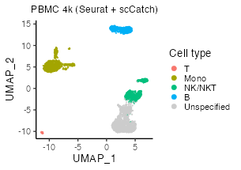

```r
title <- "PBMC 4k (Seurat + scCatch)"
labels <- factor(pbmc[[]]$cell_type,
                 levels = c("T", "Mono", "B", "NK/NKT", "Unspecified"))
mycolor <- scales::hue_pal()(5)
mycolor <- c("T" = mycolor[1], "Mono" = mycolor[2], "NK/NKT" = mycolor[3],
             "B" = mycolor[4], "Unspecified" = "grey80")
df <- pbmc@reductions[["umap"]]@cell.embeddings
p <- ggplot2::ggplot() +
  ggplot2::geom_point(ggplot2::aes(x = df[, 1], y = df[, 2], color = labels),
                      size = 1, alpha = 1) +
  ggplot2::labs(title = title, x = "UMAP_1", y = "UMAP_2", color = "Cell type") +
  ggplot2::theme_classic(base_size = 20) +
  ggplot2::theme(plot.title = ggplot2::element_text(hjust = 0.5, size = 18)) +
  ggplot2::scale_color_manual(values = mycolor) +
  ggplot2::guides(colour = ggplot2::guide_legend(override.aes = list(size = 4)))
filename <- "figures/figure_04_0245.png"
ggplot2::ggsave(file = filename, plot = p, dpi = 50, width = 6.1, height = 4.3)
```

```r
# Save data.
saveRDS(pbmc, file = "backup/04_022_pbmc4k_seurat_sccatch.rds")

# Load data.
pbmc <- readRDS("backup/04_022_pbmc4k_seurat_sccatch.rds")
```

### 7.2.6 Infer cell types using ssGSEA

Load the Seurat annotation results.

```r
pbmc <- readRDS("backup/04_021_pbmc4k_seurat.rds")
```

Check the package version.

```r
packageVersion("escape")
```

```
[1] ‘1.0.1’
```

Perform `getGeneSets()` with an argument `library = "C8"` (“cell type signature gene sets” in [MSigDB](https://www.gsea-msigdb.org/gsea/msigdb/collections.jsp)).

```r
pbmc@misc[["getGeneSets"]] <- escape::getGeneSets(species = "Homo sapiens",
                                                  library = "C8")
```

Perform `enrichIt()`, estimating ssGSEA scores, in which the arguments are the same with those in the vignettes in escape package.

```r
ES <- escape::enrichIt(obj = pbmc, gene.sets = pbmc@misc[["getGeneSets"]],
                       groups = 1000, cores = 4)
pbmc <- Seurat::AddMetaData(pbmc, ES)
pbmc@misc[["enrichIt"]] <- ES
```

```
[1] "Using sets of 1000 cells. Running 5 times."
Setting parallel calculations through a SnowParam back-end
with workers=4 and tasks=100.
Estimating ssGSEA scores for 654 gene sets.
Setting parallel calculations through a SnowParam back-end
with workers=4 and tasks=100.
Estimating ssGSEA scores for 654 gene sets.
...
Setting parallel calculations through a SnowParam back-end
with workers=4 and tasks=100.
Estimating ssGSEA scores for 654 gene sets.
```

Perform t-distributed stochastic neighbor embedding and Uniform Manifold Approximation and Projection.

```r
mat <- pbmc@misc[["enrichIt"]]
# t-SNE
set.seed(1)
res <- Rtsne::Rtsne(mat, dim = 2, pca = TRUE, initial_dims = 50)
pbmc@reductions[["tsne_ssgsea"]] <- res[["Y"]]
# UMAP
set.seed(1)
res <- umap::umap(mat, n_components = 2)
pbmc@reductions[["umap_ssgsea"]] <- res[["layout"]]
```

Perform unsupervised clustering of cells using Seurat functions.

```r
surt <- Seurat::CreateSeuratObject(counts = t(pbmc@misc[["enrichIt"]]),
                                   project = "PBMC")
surt <- Seurat::ScaleData(surt, features = rownames(surt))
surt <- Seurat::RunPCA(surt, features = rownames(surt))
surt <- Seurat::FindNeighbors(surt, reduction = "pca", dims = seq_len(40))
surt <- Seurat::FindClusters(surt, resolution = 0.1)
pbmc <- Seurat::AddMetaData(pbmc, metadata = surt[[]]$seurat_clusters,
                            col.name = "ssgsea_clusters")
```

Show the clustering results in low-dimensional spaces.

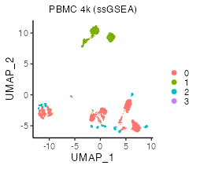

```r
labels <- pbmc$ssgsea_clusters
df <- as.data.frame(pbmc@reductions[["umap_ssgsea"]])
p <- ggplot2::ggplot() +
  ggplot2::geom_point(ggplot2::aes(x = df[, 1], y = df[, 2], color = labels),
                      size = 0.2, alpha = 1) +
  ggplot2::labs(title = "PBMC 4k (ssGSEA)", x = "UMAP_1", y = "UMAP_2",
                color = "") +
  ggplot2::theme_classic(base_size = 20) +
  ggplot2::theme(plot.title = ggplot2::element_text(hjust = 0.5, size = 18)) +
  ggplot2::guides(colour = ggplot2::guide_legend(override.aes = list(size = 4),
                                                 ncol = 1))
filename <- "figures/figure_04_0280.png"
ggplot2::ggsave(file = filename, plot = p, dpi = 50, width = 5.1, height = 4.3)
```

```r
# Save data.
saveRDS(pbmc, file = "backup/04_023_pbmc4k_ssGSEA_msigdb.rds")

# Load data.
pbmc <- readRDS("backup/04_023_pbmc4k_ssGSEA_msigdb.rds")
```

### 7.2.7 Infer cell types using Seurat and ssGSEA

Load ssGSEA results.

```r
pbmc <- readRDS("backup/04_023_pbmc4k_ssGSEA_msigdb.rds")
```

Investigate “significant” modules for Seurat clustering results.

```r
set.seed(1)
surt <- Seurat::CreateSeuratObject(counts = t(pbmc@misc[["enrichIt"]]))
surt <- Seurat::AddMetaData(surt, metadata = pbmc$cell_type,
                            col.name = "seurat_cell_type")
surt <- Seurat::SetIdent(surt, value = "seurat_cell_type")
res <- Seurat::FindAllMarkers(surt, only.pos = TRUE,
                              min.pct = 0.15, logfc.threshold = 0.15)
rownames(res) <- seq_len(nrow(res))
pbmc@misc[["ssGSEA_stat"]] <- res
```

Show violin plots for ssGSEA score distributions for Seurat annotation results.

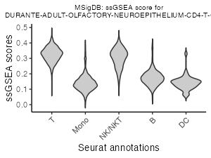

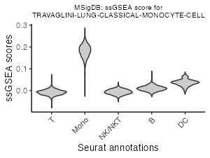

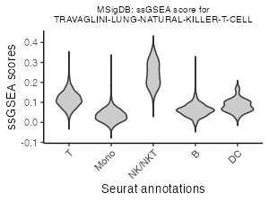

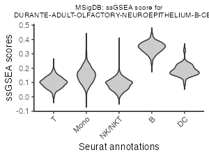

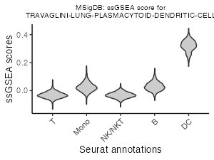

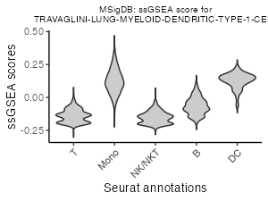

```r
lvs <- c("T", "Mono", "NK/NKT", "B", "DC")
labels <- factor(pbmc$cell_type, levels = lvs)
descriptions <- c(gsub("-", "_", "DURANTE-ADULT-OLFACTORY-NEUROEPITHELIUM-CD4-T-CELLS"),
                  gsub("-", "_", "TRAVAGLINI-LUNG-CLASSICAL-MONOCYTE-CELL"),
                  gsub("-", "_", "TRAVAGLINI-LUNG-NATURAL-KILLER-T-CELL"),
                  gsub("-", "_", "DURANTE-ADULT-OLFACTORY-NEUROEPITHELIUM-B-CELLS"),
                  gsub("-", "_", "TRAVAGLINI-LUNG-PLASMACYTOID-DENDRITIC-CELL"),
                  gsub("-", "_", "TRAVAGLINI-LUNG-MYELOID-DENDRITIC-TYPE-1-CELL"))
titles <- c(paste0("MSigDB: ssGSEA score for\n", gsub("_", "-", descriptions[1])),
            paste0("MSigDB: ssGSEA score for\n", gsub("_", "-", descriptions[2])),
            paste0("MSigDB: ssGSEA score for\n", gsub("_", "-", descriptions[3])),
            paste0("MSigDB: ssGSEA score for\n", gsub("_", "-", descriptions[4])),
            paste0("MSigDB: ssGSEA score for\n", gsub("_", "-", descriptions[5])),
            paste0("MSigDB: ssGSEA score for\n", gsub("_", "-", descriptions[6])))
mat <- pbmc@misc[["enrichIt"]]
mat <- mat[, which(colnames(mat) %in% descriptions)]
for(i in seq_along(descriptions)){
  df <- data.frame(label = labels,
                   ssGSEA = mat[, which(colnames(mat) == descriptions[i])])
#  df <- tidyr::pivot_longer(df, cols = c("Sign", "ssGSEA"))
  p <- ggplot2::ggplot() +
    ggplot2::geom_violin(ggplot2::aes(x = as.factor(df$label), y = df$ssGSEA),
                         fill = "grey80", trim = FALSE, size = 1) +
    ggplot2::labs(title = titles[i], x = "Seurat annotations",
                  y = "ssGSEA scores") +
    ggplot2::scale_x_discrete(guide = ggplot2::guide_axis(angle = 45)) +
    ggplot2::theme_classic(base_size = 20) +
    ggplot2::theme(plot.title = ggplot2::element_text(hjust = 0.5, size = 15))
  filename <- sprintf("figures/figure_04_%04d.png", 289 + i)
  ggplot2::ggsave(file = filename, plot = p, dpi = 50, width = 6, height = 4.5)
}
```

```r
# Save data.
saveRDS(pbmc, file = "backup/04_024_pbmc4k_seurat_ssGSEA.rds")

# Load data.
pbmc <- readRDS("backup/04_024_pbmc4k_seurat_ssGSEA.rds")
```

## 7.3 Monocle 3

Load the normalized data (see here).

```r
pbmc <- readRDS("backup/04_003_pbmc4k_normalized.rds")
```

Create Monocle 3 objects (cell_data_set (CDS)).

```r
gene_metadata <- data.frame(gene_short_name = rowData(pbmc)$gene)
rownames(gene_metadata) <- rowData(pbmc)$gene
pbmc <- monocle3::new_cell_data_set(
  expression_data = as.matrix(assay(pbmc, "counts")),
  cell_metadata = colData(pbmc),
  gene_metadata = gene_metadata)
```

### 7.3.1 Perform Monocle 3 preprocessing

Preprocess the data under the default settings of Monocle 3 (version 1.0.0), e.g., `num_dim = 50` and `norm_method = "log"`.

```r
pbmc <- monocle3::preprocess_cds(pbmc)
```

Perform log-normalization with a pseudo count.

```r
assay(pbmc, "logcounts") <- monocle3::normalized_counts(pbmc,
                                                        norm_method = "log",
                                                        pseudocount = 1)
```

Perform dimensionality reduction.

```r
#pbmc <- monocle3::reduce_dimension(pbmc, reduction_method = "tSNE",
#                                   preprocess_method = "PCA")
pbmc <- monocle3::reduce_dimension(pbmc, reduction_method = "UMAP",
                                   preprocess_method = "PCA")
```

### 7.3.2 Cluster cells

Group cells into several clusters by using a community detection algorithm.

```r
#pbmc <- monocle3::cluster_cells(pbmc, resolution = 5e-4, reduction_method = "tSNE")
pbmc <- monocle3::cluster_cells(pbmc, resolution = 5e-5, reduction_method = "UMAP")
```

Show the clustering results.

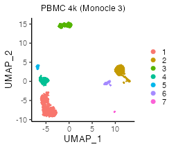

```r
title <- "PBMC 4k (Monocle 3)"
labels <- pbmc@clusters@listData[["UMAP"]][["clusters"]]
df <- reducedDim(pbmc, "UMAP")
p <- ggplot2::ggplot() +
  ggplot2::geom_point(ggplot2::aes(x = df[, 1], y = df[, 2], color = labels),
                      size = 1, alpha = 1) +
  ggplot2::labs(title = title, x = "UMAP_1", y = "UMAP_2", color = "") +
  ggplot2::theme_classic(base_size = 20) +
  ggplot2::theme(plot.title = ggplot2::element_text(hjust = 0.5, size = 18)) +
  ggplot2::scale_colour_hue() +
  ggplot2::guides(colour = ggplot2::guide_legend(override.aes = list(size = 4)))
filename <- "figures/figure_04_0330.png"
ggplot2::ggsave(file = filename, plot = p, dpi = 50, width = 5.1, height = 4.3)
```

### 7.3.3 Find differentially expressed genes

Find differentially expressed genes.

```r
set.seed(1)
metadata(pbmc)$markers <- monocle3::top_markers(pbmc, group_cells_by = "cluster",
                                                reference_cells = 1000, cores = 2)
markers <- metadata(pbmc)$markers
markers <- markers[order(markers$cell_group, markers$marker_test_q_value), ]
View(markers[which(markers$marker_test_q_value < 10^(-100)), ])
```

### 7.3.4 Infer cell types

Defining significant genes as genes with marker_teset_q_value<1e-100, infer cell types using [GeneCards](https://www.genecards.org/).

[output not shown]

```r
tmp <- as.integer(as.character(pbmc@clusters@listData[["UMAP"]][["clusters"]]))
colData(pbmc)$cell_type <- tmp
colData(pbmc)$cell_type[colData(pbmc)$cell_type == 1] <- "T"
colData(pbmc)$cell_type[colData(pbmc)$cell_type == 2] <- "Mono"
colData(pbmc)$cell_type[colData(pbmc)$cell_type == 3] <- "B"
colData(pbmc)$cell_type[colData(pbmc)$cell_type == 4] <- "NK/NKT"
colData(pbmc)$cell_type[colData(pbmc)$cell_type == 5] <- "NK/NKT"
colData(pbmc)$cell_type[colData(pbmc)$cell_type == 6] <- "Unspecified"
colData(pbmc)$cell_type[colData(pbmc)$cell_type == 7] <- "Unspecified"
colData(pbmc)$cell_type[colData(pbmc)$cell_type == 8] <- "Unspecified"
```

Show the annotation results in low-dimensional spaces.

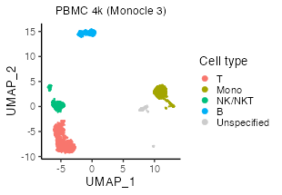

```r
title <- "PBMC 4k (Monocle 3)"
labels <- factor(colData(pbmc)$cell_type,
                 levels = c("T", "Mono", "B", "NK/NKT", "Unspecified"))
mycolor <- scales::hue_pal()(5)
mycolor <- c("T" = mycolor[1], "Mono" = mycolor[2], "NK/NKT" = mycolor[3],
             "B" = mycolor[4], "Unspecified" = "grey80")
df <- reducedDim(pbmc, "UMAP")
p <- ggplot2::ggplot() +
  ggplot2::geom_point(ggplot2::aes(x = df[, 1], y = df[, 2], color = labels),
                      size = 1, alpha = 1) +
  ggplot2::labs(title = title, x = "UMAP_1", y = "UMAP_2", color = "Cell type") +
  ggplot2::theme_classic(base_size = 20) +
  ggplot2::theme(plot.title = ggplot2::element_text(hjust = 0.5, size = 18)) +
  ggplot2::guides(colour = ggplot2::guide_legend(override.aes = list(size = 4))) +
  ggplot2::scale_color_manual(values = mycolor)
filename <- "figures/figure_04_0340.png"
ggplot2::ggsave(file = filename, plot = p, dpi = 50, width = 6.2, height = 4.3)
```

```r
# Save data.
saveRDS(pbmc, file = "backup/04_031_pbmc4k_monocle3.rds")

# Load data.
pbmc <- readRDS("backup/04_031_pbmc4k_monocle3.rds")
```

## 7.4 SC3

Load the normalized data (see here).

```r
pbmc <- readRDS("backup/04_003_pbmc4k_normalized.rds")
```

Prepare a SingleCellExperiment object.

```r
mat <- as.matrix(assay(pbmc, "counts"))
pbmc <- SingleCellExperiment(assays = list(counts = as.matrix(mat),
                                           logcounts = log2(mat + 1)),
                             rowData = data.frame(gene = rownames(mat)),
                             colData = data.frame(sample = colnames(mat)))
rowData(pbmc)$feature_symbol <- rownames(pbmc)
```

## 7.5 Cluster cells

```r
set.seed(1)
pbmc <- SC3::sc3(pbmc, ks = 4:8, biology = TRUE)
```

Plot stability indices across `ks` for investigating “optimal” number of clusters.

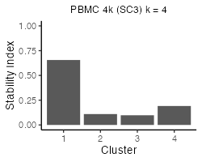

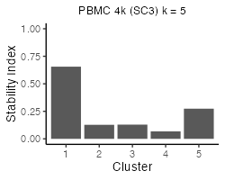

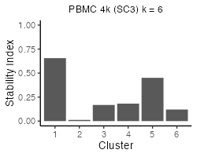

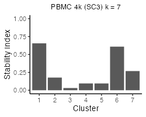

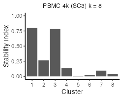

```r
kss <- as.integer(names(metadata(pbmc)$sc3$consensus))
for(i in seq_along(kss)){
  p <- SC3::sc3_plot_cluster_stability(pbmc, k = kss[i])
  p <- p + ggplot2::labs(title = paste0("PBMC 4k (SC3) k = ", kss[i])) +
    ggplot2::theme_classic(base_size = 20) +
    ggplot2::theme(plot.title = ggplot2::element_text(hjust = 0.5, size = 18))
  filename <- sprintf("figures/figure_04_%04d.png", 409 + i)
  ggplot2::ggsave(file = filename, plot = p, dpi = 50, width = 5, height = 4)
}
```

### 7.5.1 Find differentially expressed genes

Setting the optimal number of clusters, find differentially expressed genes.

```r
row_data <- rowData(pbmc)
markers <- as.data.frame(row_data[ , grep("gene|sc3_8", colnames(row_data))])
markers <- markers[order(markers$sc3_8_markers_clusts, markers$sc3_8_de_padj), ]
View(markers[which(markers$sc3_8_de_padj < 10^(-100)), ])
```

### 7.5.2 Infer cell types

Defining significant genes as genes with sc3_8_de_padj<1e-100, infer cell types using [GeneCards](https://www.genecards.org/).

[output not shown]

```r
col_data <- colData(pbmc)
clusters <- col_data[ , grep("sc3_8_clusters", colnames(col_data))]
colData(pbmc)$cell_type <- as.integer(as.character(clusters))
colData(pbmc)$cell_type[colData(pbmc)$cell_type == 1] <- "Mono"
colData(pbmc)$cell_type[colData(pbmc)$cell_type == 2] <- "T"
colData(pbmc)$cell_type[colData(pbmc)$cell_type == 3] <- "B"
colData(pbmc)$cell_type[colData(pbmc)$cell_type == 4] <- "NK/NKT"
colData(pbmc)$cell_type[colData(pbmc)$cell_type == 5] <- "T"
colData(pbmc)$cell_type[colData(pbmc)$cell_type == 6] <- "T"
colData(pbmc)$cell_type[colData(pbmc)$cell_type == 7] <- "NK/NKT"
colData(pbmc)$cell_type[colData(pbmc)$cell_type == 8] <- "T"
```

```r
# Save data.
saveRDS(pbmc, file = "backup/04_041_pbmc4k_sc3.rds")

# Load data.
pbmc <- readRDS("backup/04_041_pbmc4k_sc3.rds")
```